# C8wk08

OlivierBQ

08-10-2017

### Background of this research

Using devices such as Jawbone Up, Nike FuelBand, and Fitbit it is now possible to collect a large amount of data about personal activity relatively inexpensively. These type of devices are part of the quantified self movement – a group of enthusiasts who take measurements about themselves regularly to improve their health, to find patterns in their behavior, or because they are tech geeks. One thing that people regularly do is quantify how much of a particular activity they do, but they rarely quantify how well they do it. In this project, our goal will be to use data from accelerometers on the belt, forearm, arm, and dumbell of 6 participants. They were asked to perform barbell lifts correctly and incorrectly in 5 different ways.

More information is available from the website here: http://groupware.les.inf.puc-rio.br/har (see the section on the Weight Lifting Exercise Dataset).

### Research question

The goal of this project is to predict the manner in which they did the exercise. This is the “classe” variable in the training set. We may use any of the other variables to predict with. We should create a report describing how we built our model, how we used cross validation, what we think the expected out of sample error is, and why we made the choices we did. We will also use our prediction model to predict 20 different test cases.

### Step 1 Install packages

The first step is to install and load all the recuired packages not usually present in R.

```r
library(caret)
library(C50)
library(plyr)
library(dplyr)
library(randomForest)
library(data.table)
```

### Step 2 Data

The training data for this project are available here:

https://d396qusza40orc.cloudfront.net/predmachlearn/pml-training.csv

The test data are available here:

https://d396qusza40orc.cloudfront.net/predmachlearn/pml-testing.csv

The data for this project come from this source: http://groupware.les.inf.puc-rio.br/har. If the documents or data is used for anay other purpose please cite them as they have been very generous in allowing their data to be used for this kind of research.

After installing the packages we will load the HAR dataset which includes a training and test data file

```r
trainingFile <- "http://d396qusza40orc.cloudfront.net/predmachlearn/pml-training.csv"
testFile <- "http://d396qusza40orc.cloudfront.net/predmachlearn/pml-testing.csv"
# because of the nature of the csv file we transformed all the observations containing #DIV/0 to na, when reading the csv file this was discovered.
training <- read.csv(trainingFile, na.string= "#DIV/0!")
test <- read.csv(testFile)
```

In the exploration of the dataset we look at the different variables which are accounted for in the training dataset.

```r
head(training)
str(training)
summary(training$user_name)
summary(training$classe)
```

[output not shown]

```r
dim(training)
```

```
## [1] 19622   160
```

The results show that there are 19622 observations in the training data set with 160 observations. The dtrings are diverse with both factor as numeric In order to make a good decission how to clean up the training set we will look at the number of na’s in the dataset.

```r
na_count <- sapply(training, function(y) sum(length(which(is.na(y)))))

na_count <- data.frame(na_count)

na_count
```

[output not shown]

```r
dataset <- training[ -c(1:7) ]
for(i in c(8:ncol(dataset)-1)){dataset[,i] = as.numeric(as.character(dataset[,i]))}
dataset <- dataset[,colSums(is.na(dataset))==0]
```

```r
inTrain  <- createDataPartition(dataset$classe, p=0.75, list=FALSE)
Trainset <- dataset[inTrain, ]
Testset  <- dataset[-inTrain, ]
```

### Predictive Model Building

We start the exploration into the classification of the data by examining the different possible machine learning algorithms. In order to do so we start bu tacking a subset of the training data to enhance the proces. This subset contains 5000 randomly selected observations. We also set the traincontrol to Cross-Validation with a 10 fold cv split. The metric that we will base our decission on is the Accurracy of the different models.

```r
DS <- Trainset[sample(nrow(Trainset),5000),]
control <- trainControl(method="cv", number=10)
metric <- "Accuracy"
```

## Explore different ML model

```r
## Decision Tree
set.seed(4)
fit.dt <- train(classe~., data=DS, method="C5.0", metric=metric, trControl=control)

## PCA
set.seed(4)
fit.pca <- train(classe~., data=DS, method="multinom", metric=metric, trControl=control)

## kNN
set.seed(4)
fit.knn <- train(classe~., data=DS, method="knn", metric=metric, trControl=control)

## SVM
set.seed(4)
fit.svm1 <- train(classe~., data=DS, method="svmRadial", metric=metric, trControl=control)

## Random Forest
set.seed(4)
fit.rf1 <- train(classe~., data=DS, method="rf", metric=metric, trControl=control)
```

After all the models have been trained we will compair the results. The first overview is in a dotplot.

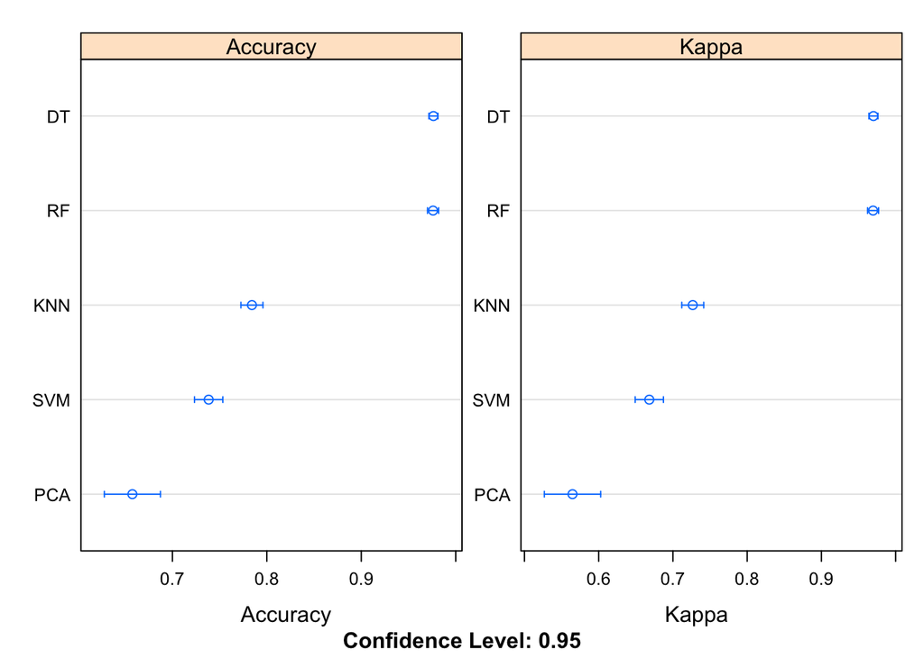

```r
# dot plots of accuracy
results <- resamples(list(DT= fit.dt, PCA=fit.pca, KNN=fit.knn, SVM=fit.svm1, RF=fit.rf1))
scales <- list(x=list(relation="free"), y=list(relation="free"))
dotplot(results, scales=scales)
```

The dotplot shows us that the decision tree and random forest are the most accurat predicters of the classe of excersise. To make a final decision we make a table containing the different results.

```r
summary(results)
```

```
##
## Call:
## summary.resamples(object = results)
##
## Models: DT, PCA, KNN, SVM, RF
## Number of resamples: 10
##
## Accuracy
##          Min.  1st Qu.    Median      Mean   3rd Qu.      Max. NA's
## DT  0.9619238 0.974013 0.9770240 0.9763992 0.9795000 0.9860000    0
## PCA 0.5580000 0.646000 0.6673214 0.6576115 0.6833667 0.7020000    0
## KNN 0.7564870 0.777000 0.7887896 0.7842077 0.7936038 0.8080000    0
## SVM 0.7094188 0.721500 0.7347415 0.7383936 0.7575000 0.7664671    0
## RF  0.9619238 0.972000 0.9770259 0.9760020 0.9815000 0.9879760    0
##
## Kappa
##          Min.   1st Qu.    Median      Mean   3rd Qu.      Max. NA's
## DT  0.9518095 0.9671007 0.9709181 0.9701277 0.9740429 0.9822978    0
## PCA 0.4371291 0.5494510 0.5769726 0.5647270 0.5981664 0.6189804    0
## KNN 0.6913919 0.7178277 0.7324655 0.7267116 0.7388823 0.7568266    0
## SVM 0.6316950 0.6471106 0.6633143 0.6681955 0.6927504 0.7041488    0
## RF  0.9518242 0.9645412 0.9709149 0.9696229 0.9765720 0.9847775    0
```

```r
##Use the most acurate methode to make the modfit algorithm on the whole training set


modfit <- train(classe~., data=Trainset, method="rf", metric=metric, trControl=control, ntree=50)

confusionMatrix(modfit)
```

```
## Cross-Validated (10 fold) Confusion Matrix
##
## (entries are percentual average cell counts across resamples)
##
##           Reference
## Prediction    A    B    C    D    E
##          A 28.4  0.1  0.0  0.0  0.0
##          B  0.0 19.1  0.1  0.0  0.0
##          C  0.0  0.1 17.3  0.2  0.0
##          D  0.0  0.0  0.1 16.2  0.1
##          E  0.0  0.0  0.0  0.0 18.3
##
##  Accuracy (average) : 0.9927
```

The confusion matrix shows a 99 percent accurracy in predicting the class.

```r
predictTest <- predict(modfit, Testset)

Testset$classepred <- predictTest
```

```r
confusionMatrix(table(Testset$classepred, Testset$classe))
```

```
## Confusion Matrix and Statistics
##
##
##        A    B    C    D    E
##   A 1394    1    0    0    0
##   B    0  948    2    0    0
##   C    1    0  853    6    1
##   D    0    0    0  798    0
##   E    0    0    0    0  900
##
## Overall Statistics
##
##                Accuracy : 0.9978
##                  95% CI : (0.996, 0.9989)
##     No Information Rate : 0.2845
##     P-Value [Acc > NIR] : < 2.2e-16
##
##                   Kappa : 0.9972
##  Mcnemar's Test P-Value : NA
##
## Statistics by Class:
##
##                      Class: A Class: B Class: C Class: D Class: E
## Sensitivity            0.9993   0.9989   0.9977   0.9925   0.9989
## Specificity            0.9997   0.9995   0.9980   1.0000   1.0000
## Pos Pred Value         0.9993   0.9979   0.9907   1.0000   1.0000
## Neg Pred Value         0.9997   0.9997   0.9995   0.9985   0.9998
## Prevalence             0.2845   0.1935   0.1743   0.1639   0.1837
## Detection Rate         0.2843   0.1933   0.1739   0.1627   0.1835
## Detection Prevalence   0.2845   0.1937   0.1756   0.1627   0.1835
## Balanced Accuracy      0.9995   0.9992   0.9978   0.9963   0.9994
```

The training test set also show a really high accuracy of 99.8 percent. We can conclude that the model is accurate so we will use it to get on with the final step predicting the class of the test set.

## Predicting the test outcome

In the trainingset the model shows to have a good accurracy in predicting the classe of the observations. Next up we will use the model to predict the classe of a testset where the classe is unknown.

```r
dim(test)
```

```
## [1]  20 160
```

```r
Predict <- predict(modfit, test)
```

The results of the prediction is shown below

```r
df.Predict <- transpose(data.frame(Predict))
names(df.Predict) <- c(1:20)

df.Predict
```

```
##   1 2 3 4 5 6 7 8 9 10 11 12 13 14 15 16 17 18 19 20
## 1 B A B A A E D B A  A  B  C  B  A  E  E  A  B  B  B
```